# TriClimate Analysis

2023MCS120028-Pradeepa S

**OBJECTIVES**

The objectives for this project:

```
  1.Analysis of maximum temperatures pattern in  8 cities.

  2.Analysis of average percipitation pattern in 8 cities.

  3.Seasonal Analysis of Wind speed Range  in a  specific city.

  4.Assessing AQI Variation Across Different Periods in Multiple Cities

  5.Analysis of AQI buckets by city registered in high AQI.

  6.Correlation Analysis Among Temperature, Precipitation, and AQI.

  7.Analysis of how many stations are active among the total stations.

  8.Interactive map dispalying maximum temperature and percipation.

  9.prediction of AQI based on air quality parameter
```

PREMILINARY ANALYSIS

The following libraries are used for analysis

```r
library(ggplot2)
library(dplyr)
library(tidyr)
library(forcats)
library(stringr)
library(readr)
library(purrr)
library(lubridate)
library(naniar)
library(leaflet)
```

**Importing and preprocessing the datasets**

Importing Airquality dataset

```r
#Importing Airquality dataset
city_day <- read.csv('~/Datasets/Air_Quality/city_day.csv')
city_hour <- read.csv('~/Datasets/Air_Quality/city_hour.csv')
station_day <- read.csv('~/Datasets/Air_Quality/station_day.csv')
station_hour <- read.csv('~/Datasets/Air_Quality/station_hour.csv')
AQ_station <- read.csv('~/Datasets/Air_Quality/stations.csv')

#Importing Weather dataset

bang_weather <- read.csv('~/Datasets/Temperature_And_Precipitation_Cities_IN/Bangalore_1990_2022_BangaloreCity.csv')

chennai_weather <- read.csv('~/Datasets/Temperature_And_Precipitation_Cities_IN/Chennai_1990_2022_Madras.csv')

delhi_weather <- read.csv('~/Datasets/Temperature_And_Precipitation_Cities_IN/Delhi_NCR_1990_2022_Safdarjung.csv')

lucknow_weather <- read.csv('~/Datasets/Temperature_And_Precipitation_Cities_IN/Lucknow_1990_2022.csv')

Mumbai_weather <- read.csv('~/Datasets/Temperature_And_Precipitation_Cities_IN/Mumbai_1990_2022_Santacruz.csv')

Rajastan_weather <- read.csv('~/Datasets/Temperature_And_Precipitation_Cities_IN/Rajasthan_1990_2022_Jodhpur.csv')

Bhubhneswar_weather <- read.csv('~/Datasets/Temperature_And_Precipitation_Cities_IN/weather_Bhubhneshwar_1990_2022.csv')

Rourkela_weather <- read.csv('~/Datasets/Temperature_And_Precipitation_Cities_IN/weather_Rourkela_2021_2022.csv')
station   <- read.csv('~/Datasets/Temperature_And_Precipitation_Cities_IN/Station_GeoLocation_Longitute_Latitude_Elevation_EPSG_4326.csv')
```

Aggregating temperature data from multiple cities for streamlined analysis, including a distinct ‘City’ column for clear identification and comprehensive evaluation.

```r
chennai_weather$city <- "Chennai"
Mumbai_weather$city <- "Mumbai"
delhi_weather$city <- "Delhi"
bang_weather$city <- "Bangalore"
lucknow_weather$city <- "Lucknow"
Rajastan_weather$city <- "Rajastan"
Bhubhneswar_weather$city <- "Bubhneshwar"
Rourkela_weather$city <- "Rourkela"
Bhubhneswar_weather_comp <- Bhubhneswar_weather[,c("time","tavg","tmin","tmax","prcp","city")]
Rourkela_weather_comp <- Rourkela_weather[,c("time","tavg","tmin","tmax","prcp","city")]
# Bind into a single dataframe
weather <- rbind(chennai_weather, Mumbai_weather, delhi_weather,bang_weather,lucknow_weather,Rajastan_weather,Bhubhneswar_weather_comp,Rourkela_weather_comp)

# Identify rows that are likely yyyy-mm-dd
inds <- grep("^[0-9]{4}", weather$time)

# Extract those dates
dates <- weather$time[inds]

# Convert to Date class
dates <- as.Date(dates, "%Y-%m-%d")

# Reformat to dd-mm-yyyy
dates <- format(dates, "%d-%m-%Y")

# Replace these dates back into original column
weather$time[inds] <- dates

# Now convert entire column to Date class
weather$time <- as.Date(weather$time, "%d-%m-%Y")
```

Visualizing the distribution of missing values through graphical representation.

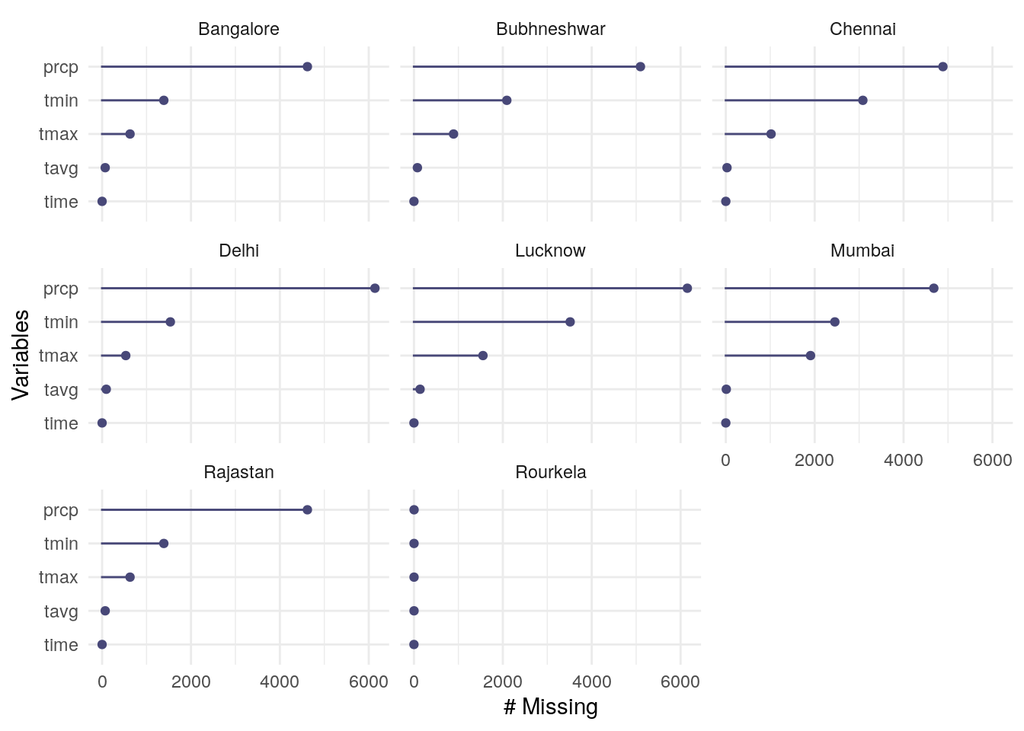

```r
gg_miss_var(weather, facet = city)
```

**DETAILED ANALYSIS**

**1.visualizes the maximum temperatures by city over the specified time period.**

```
The weather dataset  first fiter year 2012 to 2022 and then group by city wise.the generated data then visualizes these maximum temperatures by city over the specified time period.
```

```r
weather_10yr <- weather %>%
  filter(year(time) >= 2012 & year(time) <= 2022)  # Update filtering condition

# Group by city and year, get max temp
temp_summary <- weather_10yr %>%
  group_by(city, year = year(time)) %>%
  summarize(max_temp = max(tmax, na.rm = TRUE))
```

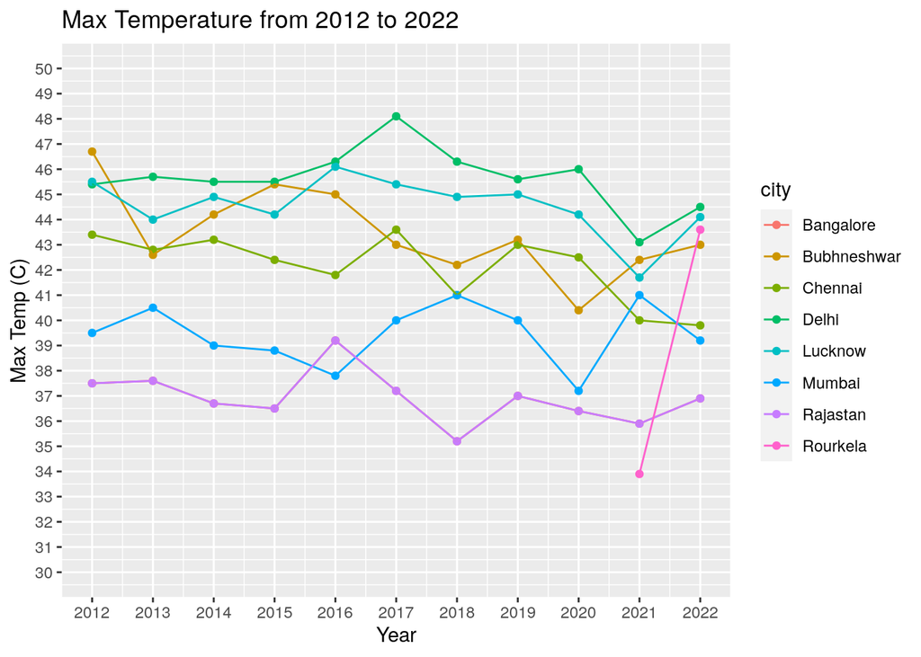

```r
# Plot max temp by city and year
ggplot(temp_summary, aes(x = year, y = max_temp, col = city)) +
  geom_point() +
  geom_line(aes(group = city)) +
  labs(title = "Max Temperature from 2012 to 2022",
       x = "Year",
       y = "Max Temp (C)") +
  scale_x_continuous(
    limits = c(2012, 2022),  # Set x-axis limits from 2012 to 2022
    breaks = seq(2012, 2022, by = 1)  # Set breaks at whole number intervals
  ) +
  scale_y_continuous(
    limits = c(30, 50),  # Set y-axis limits from 35 to 40 degrees Celsius
    breaks = seq(30, 50, by = 1)  # Set breaks at intervals of 1 degree Celsius
  )
```

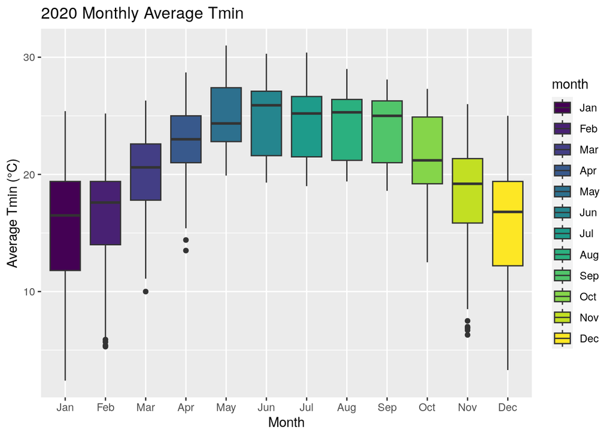

```r
# Filter for only year 2022
weather_2020 <- weather %>%
  filter(year(time) == 2020)

# Extract month
weather_2020 <- weather_2020 %>%
  mutate(month = month(time, label = TRUE))


# Box plots for tmin, tmax, and tavg temperature by month
ggplot(weather_2020, aes(x = month, y = tmin, fill = month)) +
  geom_boxplot() +
  labs(title = "2020 Monthly Average Tmin",
       x = "Month",
       y = "Average Tmin (°C)")
```

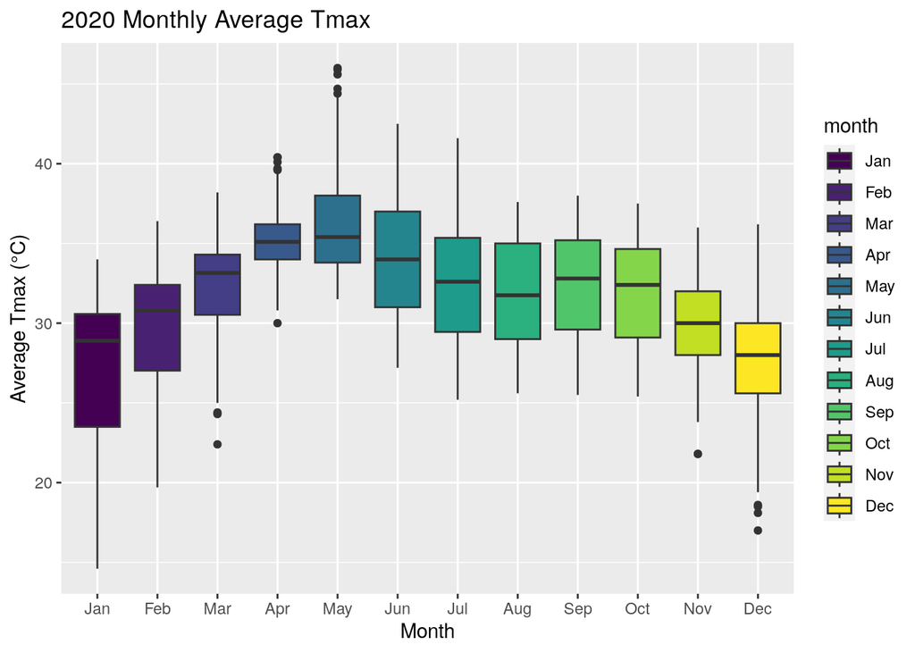

```r
ggplot(weather_2020, aes(x = month, y = tmax, fill = month)) +
  geom_boxplot() +
  labs(title = "2020 Monthly Average Tmax",
       x = "Month",
       y = "Average Tmax (°C)")
```

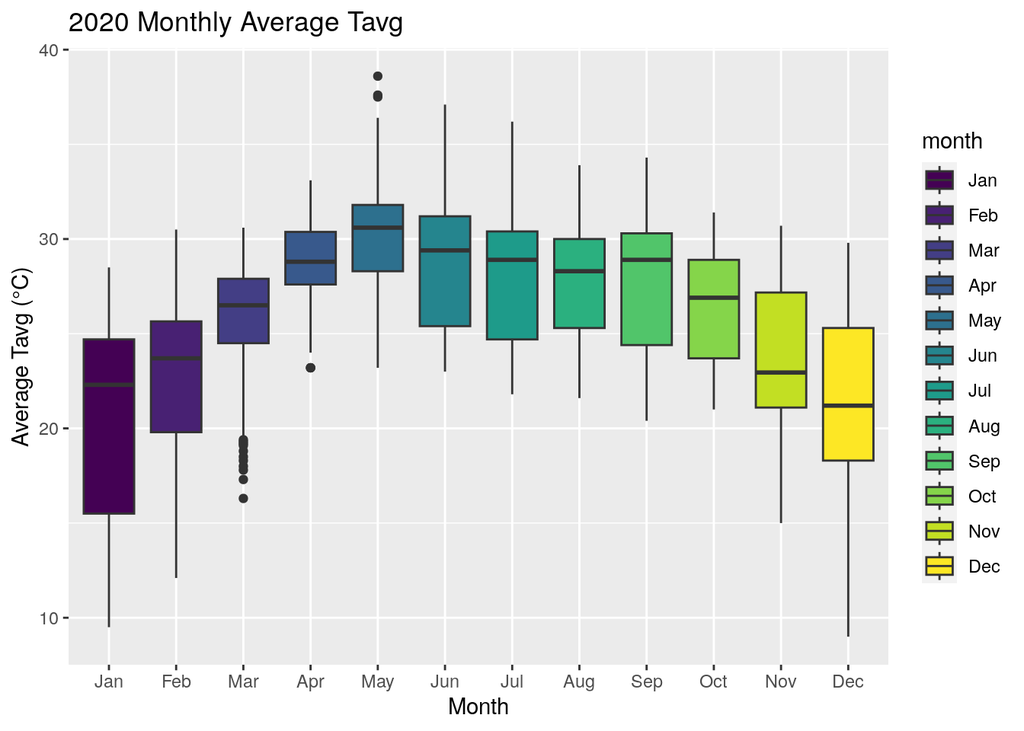

```r
ggplot(weather_2020, aes(x = month, y = tavg, fill = month)) +
  geom_boxplot() +
  labs(title = "2020 Monthly Average Tavg",
       x = "Month",
       y = "Average Tavg (°C)")
```

**3.Analysis of yearly average percipitation for each city**

```r
# Calculate yearly average temperature for each city
avg_prcp_yearly <- weather %>%
  group_by(year = year(time), city) %>%
  summarize(avg_prcp = mean(prcp, na.rm = TRUE))
```

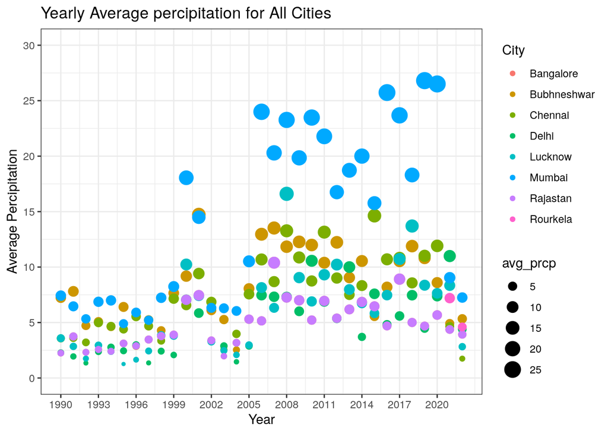

```r
# Plotting the yearly average temperature for each city
ggplot(avg_prcp_yearly, aes(x = year, y = avg_prcp, color = city, size = avg_prcp)) +
  geom_point() +
  labs(
    title = "Yearly Average percipitation for All Cities",
    x = "Year",
    y = "Average Percipitation",
    color = "City"
  ) +
  scale_x_continuous(
    limits = c(1990, 2022),
    breaks = seq(1990, 2022, by = 3)
  ) +
scale_y_continuous(
    limits = c(0, 30),
    breaks = seq(0, 30, by = 5)
  ) +

  scale_color_discrete(name = "City") +
  theme_bw()
```

**4.Visualizes the top 10 hottest temperature and precipitation**

Identifies and prints the top 10 hottest temperatures recorded across cities, displaying the temperature, city, and date of each extreme event. It then extracts and displays the highest recorded rainfall in the same manner, showcasing the precipitation, associated city, and respective dates for these extreme weather instances.

```r
top_hottest <- weather[order(-weather$tmax),][1:10,]
top_hot <- tibble(temperature = top_hottest$tmax,
                  city = top_hottest$city,
                  Date = top_hottest$time)
print(top_hot)
```

```
## # A tibble: 10 × 3
##    temperature city        Date
##          <dbl> <chr>       <date>
##  1        48.1 Delhi       2017-06-04
##  2        47.3 Delhi       1991-05-25
##  3        47.3 Lucknow     1995-06-15
##  4        47.3 Lucknow     1995-06-16
##  5        47.3 Lucknow     1995-06-17
##  6        47.1 Delhi       2017-06-05
##  7        46.7 Bubhneshwar 2012-06-05
##  8        46.6 Lucknow     1995-05-31
##  9        46.6 Lucknow     1995-06-01
## 10        46.6 Bubhneshwar 2012-06-06
```

```r
top_rain <- weather[order(-weather$prcp),][1:10,]
top_rainfall <- tibble(percipitation = top_rain$prcp,
                  city = top_rain$city,
                  Date = top_rain$time)
print(top_rainfall)
```

```
## # A tibble: 10 × 3
##    percipitation city        Date
##            <dbl> <chr>       <date>
##  1          471. Lucknow     1993-09-01
##  2          471. Bubhneshwar 1991-01-13
##  3          462  Lucknow     1998-05-07
##  4          461  Mumbai      2005-07-26
##  5          399  Mumbai      1991-06-10
##  6          375. Mumbai      2019-07-02
##  7          362. Bubhneshwar 1990-12-16
##  8          361. Lucknow     2008-05-23
##  9          352  Bubhneshwar 1995-10-22
## 10          351  Mumbai      1991-06-09
```

**5.Seasonal Analysis of Wind speed Range in a Rourkela city**

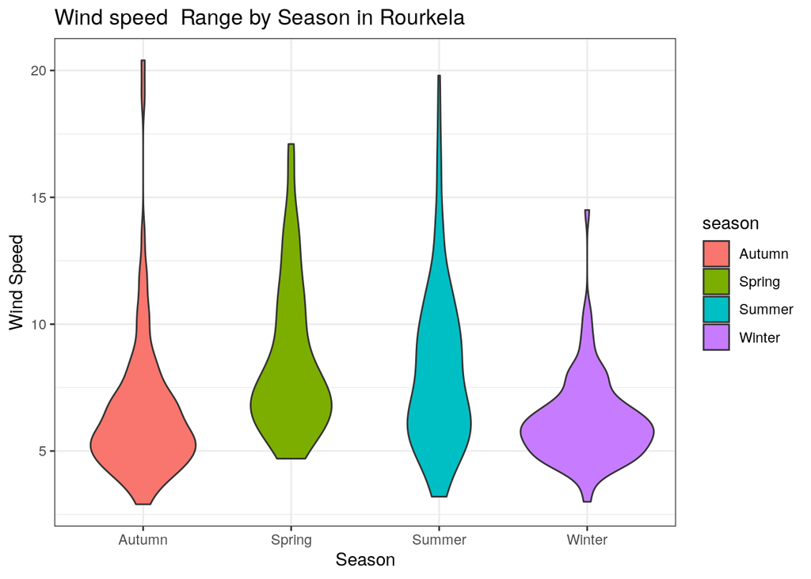

```r
# Extract the season from the date/time column
weather_season <- Rourkela_weather%>%
  mutate(season = case_when(
    month(time) %in% c(12, 1, 2) ~ "Winter",
    month(time) %in% c(3, 4, 5) ~ "Spring",
    month(time) %in% c(6, 7, 8) ~ "Summer",
    month(time) %in% c(9, 10, 11) ~ "Autumn"
  ))

# Create violin plots
ggplot(weather_season, aes(x = season, y =wspd,fill=season))+
  geom_violin() +
  labs(
    title = "Wind speed  Range by Season in Rourkela",
    x = "Season",
    y = "Wind Speed"
  ) +
  theme_bw()
```

**6.Heat map analysis of chennai city Monthly Precipitation**

```r
# Filter for Chennai
chennai <- weather %>%
  filter(city == "Chennai")

# Convert the "time" column to Date format if it's not already
chennai <- chennai %>%
  mutate(time = as.Date(time, format = "%d-%m-%Y"))

# Aggregate the precipitation data by year and month
chennai_monthly <- chennai %>%
  group_by(year = year(time), month = month(time)) %>%
  summarise(prcp = sum(prcp, na.rm = TRUE))
```

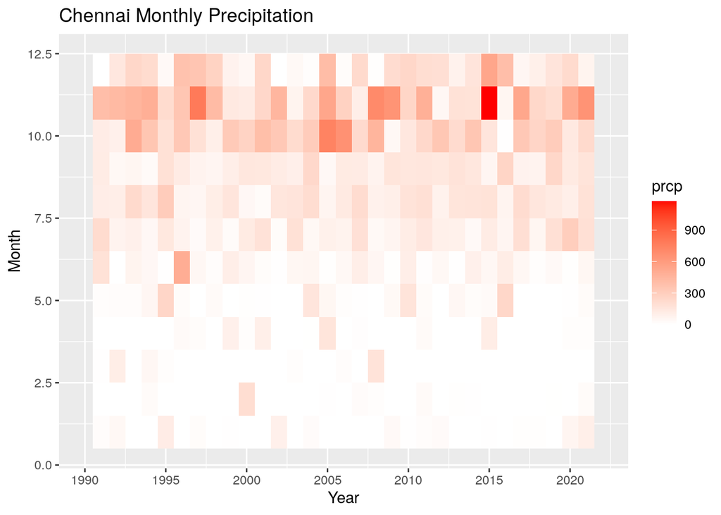

```r
# Create a heatmap
ggplot(chennai_monthly, aes(x = year, y = month, fill = prcp)) +
  geom_tile() +
  scale_fill_gradient(low = "white", high = "red") +
  labs(title = "Chennai Monthly Precipitation",
       x = "Year",
       y = "Month")+scale_x_continuous(
    limits = c(1990, 2022),  # Set x-axis limits from 2012 to 2022
    breaks = seq(1990, 2022, by = 5)  # Set breaks at whole number intervals
  )
```

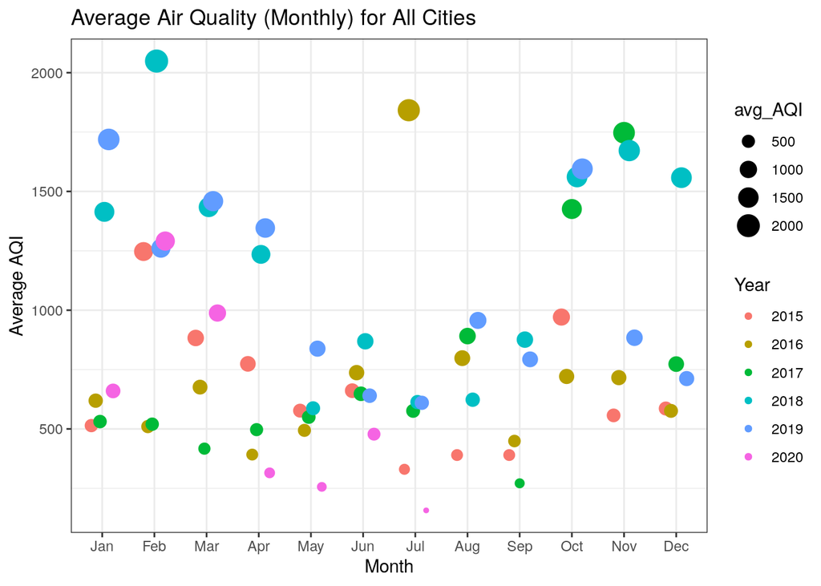

```r
# Convert the "Date" column to a Date type
city_day$Date <- as.Date(city_day$Date)

# Extract year and month from the Date column
city_day <- city_day %>%
  mutate(Year = year(Date), Month = month(Date, label = TRUE))

# Calculate the average AQI for each Year-Month combination
avg_air_quality <- city_day %>%
  group_by(Year, Month) %>%
  summarize(avg_AQI = max(AQI, na.rm = TRUE), .groups = 'drop')

# Create a point graph
ggplot(avg_air_quality, aes(x = Month, y = avg_AQI, color = factor(Year),size= avg_AQI)) +
  geom_point(position = position_dodge(width = 0.5)) +theme_bw()+
  labs(
    title = "Average Air Quality (Monthly) for All Cities",
    x = "Month",
    y = "Average AQI",
    color = "Year"
  )
```

**8.Analysis of Average AQI by Period of the Day**

```r
# Define a function to categorize the period of the day
categorize_period <- function(datetime) {
  hour <- hour(datetime)
  if (hour >= 4 && hour < 12) {
    return("Morning")
  } else if (hour >= 12 && hour < 17) {
    return("Afternoon")
  } else if (hour >= 17 && hour < 21) {
    return("Evening")
  } else {
    return("Night")
  }
}

# Add a new column for the period of the day
city_hour <- city_hour %>%
  mutate(PeriodOfDay = sapply(Datetime, categorize_period))

# Calculate the average AQI for each period of the day and City
avg_aqi_period <- city_hour %>%
  group_by(PeriodOfDay, City) %>%
  summarize(avg_AQI = mean(AQI, na.rm = TRUE))
```

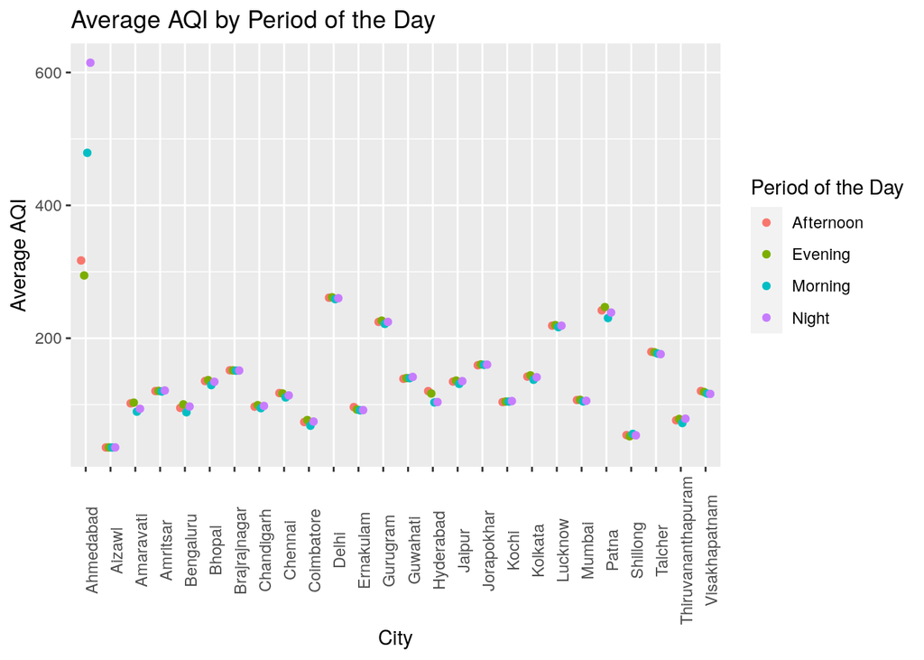

```r
# Create an  point graph by period of the day
 ggplot(avg_aqi_period, aes(x = City, y = avg_AQI, color = PeriodOfDay)) +
  geom_point(position = position_dodge(width = 0.5)) +
  labs(
    title = "Average AQI by Period of the Day",
    x = "City",
    y = "Average AQI",
    color = "Period of the Day"
  ) +theme(axis.text.x = element_text(angle=90))
```

**9.Analysis of top AQI registered cities**

```r
top_AQI <- city_day[order(-city_day$AQI),][1:5,]
top_AQI1 <- tibble(AQI = top_AQI$AQI,
                  city = top_AQI$City,
                  Date = top_AQI$Date)
print(top_AQI1)
```

```
## # A tibble: 5 × 3
##     AQI city      Date
##   <dbl> <chr>     <date>
## 1  2049 Ahmedabad 2018-02-19
## 2  1917 Ahmedabad 2018-02-10
## 3  1842 Ahmedabad 2016-07-14
## 4  1747 Ahmedabad 2017-11-14
## 5  1719 Ahmedabad 2019-01-03
```

In 2018, Ahmedabad exhibited the highest AQI recorded. Further delving into the city’s AQI could provide a comprehensive understanding of the varied AQI levels within Ahmedabad.

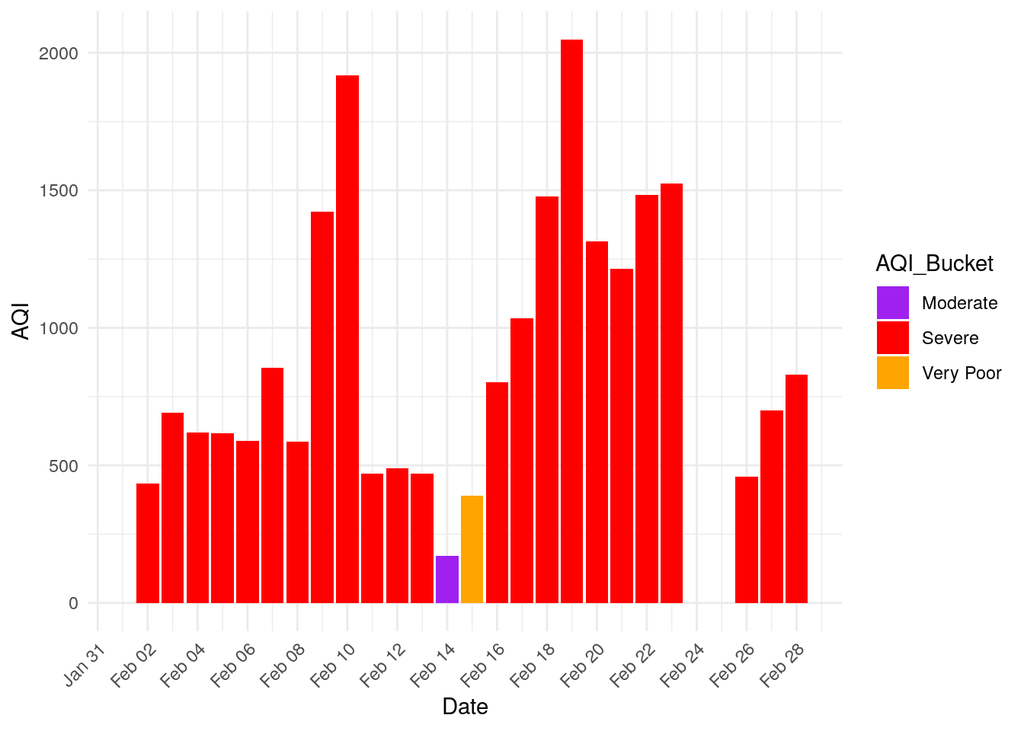

```r
# Convert the Date column to Date format
city_day$Date <- as.Date(city_day$Date)

# Filter the dataset for Ahmedabad in February 2018
ahmedabad_feb_2018_data <- city_day %>%
  filter(City == "Ahmedabad" & format(Date, "%Y-%m") == "2018-02")

# Create a bar plot with color variation based on AQI_Bucket
ggplot(data = ahmedabad_feb_2018_data, aes(x = Date, y = AQI, fill = AQI_Bucket)) +
  geom_col() +
  labs(x = "Date", y = "AQI") +
  scale_fill_manual(values = c("Good" = "green", "Satisfactory" = "yellow", "Moderate" = "purple",
                              "Poor" = "maroon", "Very Poor" = "orange", "Severe" = "red")) +
  scale_x_date(
    limits = as.Date(c("2018-02-01", "2018-02-29")),  # Set x-axis limits for February 2018
    date_breaks = "2 day",  # Set breaks at one-day intervals
    date_labels = "%b %d"  # Format x-axis labels as abbreviated month and day
  ) +
  theme_minimal() +
  theme(axis.text.x = element_text(angle = 45, hjust = 1))  # Rotate x-axis labels for readability
```

```r
# Count the number of days in each AQI Bucket category
count_data <- ahmedabad_feb_2018_data %>%
  group_by(AQI_Bucket) %>%
  summarize(Days = n())
```

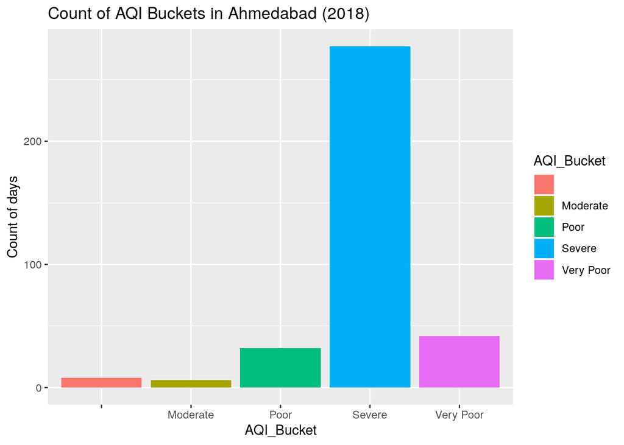

```r
ahmedabad_data <- city_day %>%
  filter(City == "Ahmedabad", year(Date) == 2018)

ggplot(data = ahmedabad_data, aes(x = AQI_Bucket, fill = AQI_Bucket)) +
  geom_bar() +
  labs(x = "AQI_Bucket", y = "Count of days") +
  ggtitle("Count of AQI Buckets in Ahmedabad (2018)")
```

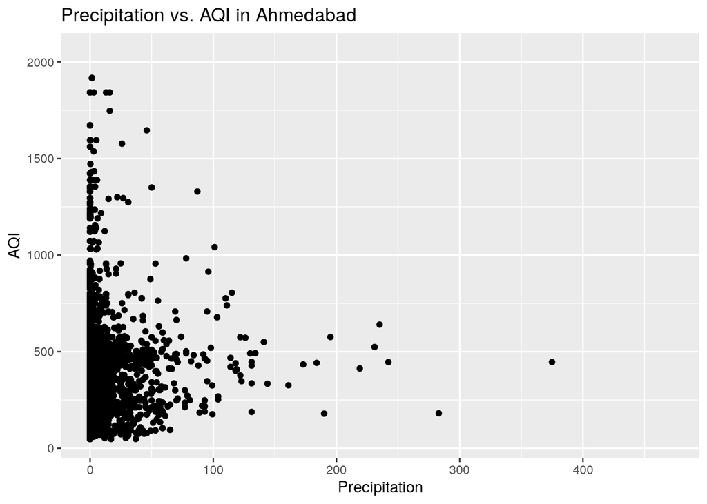

```r
ahmedabad_data <- city_day %>%
  filter(City == "Ahmedabad")

# Extract required columns from the weather dataset
weather_subset <- weather %>%
  select(time, prcp,tmax)

# Extract required columns from the city_day dataset
city_day_subset <- ahmedabad_data %>%
  select(Date, AQI)

# Convert the time column in the weather dataset to Date format
weather_subset$time <- as.Date(weather_subset$time)

# Convert the Date column in the city_day dataset to Date format
city_day_subset$Date <- as.Date(city_day_subset$Date)

# Merge the two datasets based on the Date column
merged_data <- merge(weather_subset, city_day_subset, by.x = "time", by.y = "Date", all.x = TRUE)

# Plot the line graph
ggplot(merged_data, aes(x = prcp, y = AQI)) +
  geom_point() +
  labs(x = "Precipitation", y = "AQI", title = "Precipitation vs. AQI in Ahmedabad")
```

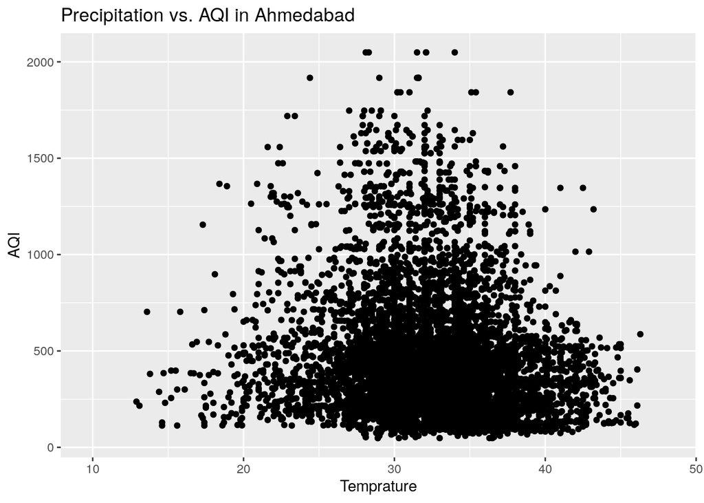

```r
ggplot(merged_data, aes(x = tmax, y = AQI)) +
  geom_point() +
  labs(x = "Temprature", y = "AQI", title = "Precipitation vs. AQI in Ahmedabad")
```

**11.Interactive map dispalying maximum temperature and percipation**

```r
library(htmltools)


# Filter station data for top 5 cities with max temperature
temp_station <- station[station$Location_Name %in% top_hot$city, ]

# Filter station data for top 5 cities with max precipitation
prcp_station <- station[station$Location_Name %in% top_rainfall$city, ]

m4 <- leaflet() %>%
  addTiles() %>%
  addCircleMarkers(
    data = temp_station,
    radius = 5,
    color = "red",
    fillColor = "red",
    fillOpacity = 0.5,
    lng = ~longitude,
    lat = ~Latitude,
    label = ~Location_Name,
    labelOptions = labelOptions(noHide = TRUE),
    group = "Temperature"
  ) %>%
  addCircleMarkers(
    data = prcp_station,
    radius = 5,
    color = "green",
    fillColor = "green",
    fillOpacity = 0.5,
    lng = ~longitude,
    lat = ~Latitude,
    label = ~Location_Name,
    labelOptions = labelOptions(noHide = TRUE),
    group = "Precipitation"
  ) %>%
  addLayersControl(
    overlayGroups = c("Temperature", "Precipitation"),
    options = layersControlOptions(collapsed = FALSE)
  ) %>%
  setView(lng = 78.9629, lat = 20.5937, zoom = 5)

m4
```

[interactive chart not shown]

**12.Analysis of how many stations are active among the total stations.**

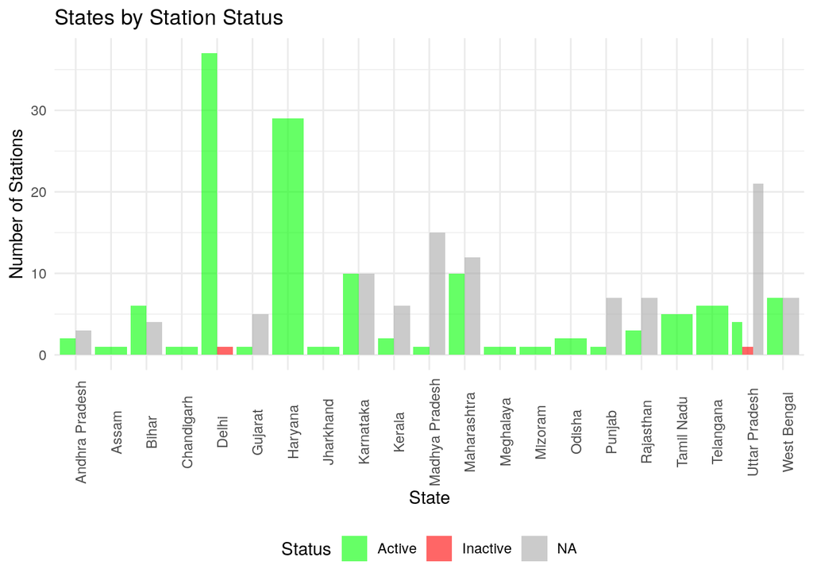

```r
AQ_station %>%
  mutate(Status = na_if(Status, "")) %>%
  group_by(State, Status) %>%
  summarise(c = n_distinct(StationName)) %>%
  arrange(desc(c)) %>%
  ggplot(aes(State, c, fill = Status)) +
  geom_bar(stat = "identity", position = "dodge", alpha = 0.6) +
  scale_fill_manual(values = c("green", "red"), na.value = " darkgray") +
  theme_minimal() +
  theme(axis.text.x = element_text(angle = 90), legend.position = "bottom") +
  labs(title = "States by Station Status", x = "State", y = "Number of Stations")
```

**13.prediction of AQI based on air quality parameter using linear model**

```r
library(caret)
```

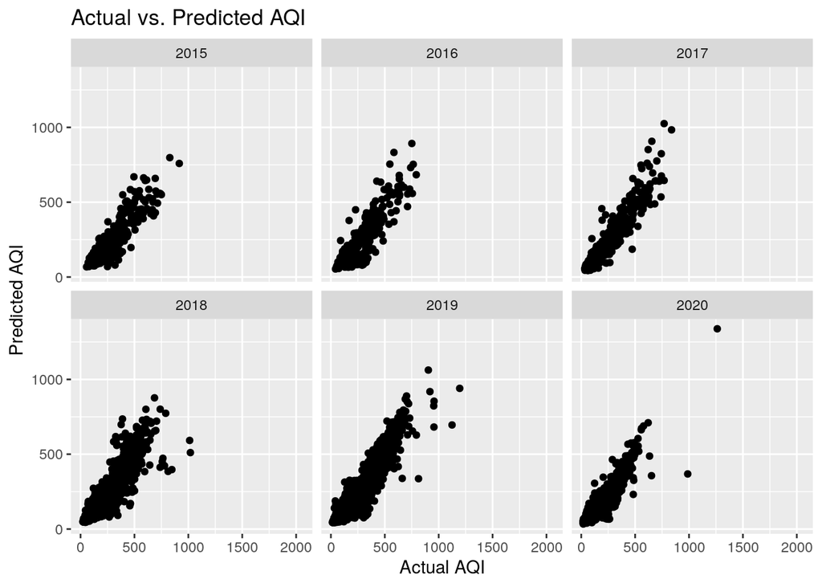

```r
# Separate data into complete and incomplete (missing AQI) observations
complete_data <- station_day %>%
  filter(!is.na(AQI))

incomplete_data <- station_day %>%
  filter(is.na(AQI))

# Split complete data into training and testing sets
set.seed(123)
index <- createDataPartition(complete_data$AQI, p = 0.7, list = FALSE)
train_data <- complete_data[index, ]
test_data <- complete_data[-index, ]
test_data$Date <- as.Date(test_data$Date)

# Train model using specific features and generate predictions
lm_model <- lm(AQI ~ PM2.5 + PM10 + CO, data = train_data)
predictions <- predict(lm_model, newdata = test_data)

# Create results dataframe
results <- data.frame(Actual = test_data$AQI, Predicted = predictions,Year = as.numeric(format(test_data$Date, "%Y")))

# Plot Actual vs. Predicted AQI
ggplot(results, aes(Actual, Predicted)) +
  geom_point() +
  labs(x = "Actual AQI", y = "Predicted AQI") +facet_wrap(~Year)+
  ggtitle('Actual vs. Predicted AQI')
```

**OUTCOMES**

On analyzing the different datasets,the following outcomes were able to achieve,

[output not shown]

**RESULTS AND DISCUSSIONS**

[output not shown]